# Shrinkage: sparsifying priors

Peter Ralph

Advanced Biological Statistics

# Overfitting: when you have too much information

## Example data

from Efron, Hastie, Johnstone, & Tibshirani

```r
library(lars)
data(diabetes)
class(diabetes$x2) <- "matrix"
```

[output not shown]

The dataset has

- 442 diabetes patients
- 10 main variables: age, gender, body mass index, average blood pressure (map), and six blood serum measurements (tc, ldl, hdl, tch, ltg, glu)
- 45 interactions, e.g. `age:ldl`
- 9 quadratic effects, e.g. `age^2`
- measure of disease progression taken one year later: `y`

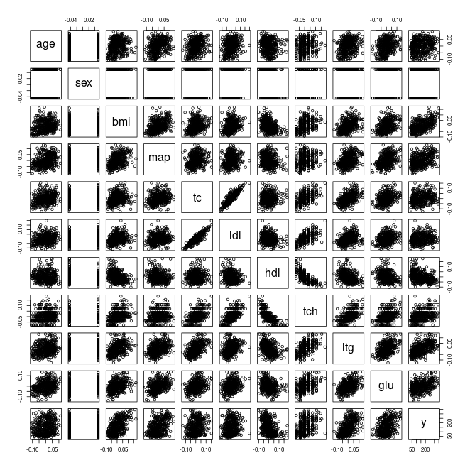

```r
cor(cbind(diabetes$x, y=diabetes$y))
```

```
##        age    sex    bmi   map    tc   ldl    hdl   tch   ltg   glu      y
## age  1.000  0.174  0.185  0.34 0.260  0.22 -0.075  0.20  0.27  0.30  0.188
## sex  0.174  1.000  0.088  0.24 0.035  0.14 -0.379  0.33  0.15  0.21  0.043
## bmi  0.185  0.088  1.000  0.40 0.250  0.26 -0.367  0.41  0.45  0.39  0.586
## map  0.335  0.241  0.395  1.00 0.242  0.19 -0.179  0.26  0.39  0.39  0.441
## tc   0.260  0.035  0.250  0.24 1.000  0.90  0.052  0.54  0.52  0.33  0.212
## ldl  0.219  0.143  0.261  0.19 0.897  1.00 -0.196  0.66  0.32  0.29  0.174
## hdl -0.075 -0.379 -0.367 -0.18 0.052 -0.20  1.000 -0.74 -0.40 -0.27 -0.395
## tch  0.204  0.332  0.414  0.26 0.542  0.66 -0.738  1.00  0.62  0.42  0.430
## ltg  0.271  0.150  0.446  0.39 0.516  0.32 -0.399  0.62  1.00  0.46  0.566
## glu  0.302  0.208  0.389  0.39 0.326  0.29 -0.274  0.42  0.46  1.00  0.382
## y    0.188  0.043  0.586  0.44 0.212  0.17 -0.395  0.43  0.57  0.38  1.000
```

## Crossvalidation plan

1. Put aside 20% of the data for *testing*.
2. Refit the model.
3. Predict the test data; compute
   $$\begin{aligned}
   S = \sqrt{\frac{1}{M} \sum_{k=1}^M (\hat y_i - y_i)^2}
   \end{aligned}$$
4. Repeat for the other four 20%s.
5. Compare.

## Crossvalidation

First let’s split the data into testing and training just once:

```r
test_observations <- (rbinom(nrow(diabetes), size=1, prob=0.2) == 1)
test_d <- cbind(data.frame(y=diabetes$y[test_observations]),
                diabetes$x2[test_observations,])
training_d <- cbind(data.frame(y=diabetes$y[!test_observations]),
                diabetes$x2[!test_observations,])
```

## Ordinary least squares

```r
ols <- lm(y ~ ., data=training_d)
summary(ols)
```

```
##
## Call:
## lm(formula = y ~ ., data = training_d)
##
## Residuals:
##    Min     1Q Median     3Q    Max
## -144.3  -32.5   -1.1   30.8  150.4
##
## Coefficients:
##              Estimate Std. Error t value Pr(>|t|)
## (Intercept)   150.688      2.952   51.04  < 2e-16 ***
## age            84.949     76.868    1.11  0.27004
## sex          -269.634     74.608   -3.61  0.00036 ***
## bmi           472.782     95.168    4.97  1.2e-06 ***
## map           360.868     83.425    4.33  2.1e-05 ***
## tc          -5344.136  61836.313   -0.09  0.93119
## ldl          4723.000  54348.535    0.09  0.93081
## hdl          1680.538  23107.326    0.07  0.94207
## tch           -85.184    310.280   -0.27  0.78387
## ltg          2350.565  20327.550    0.12  0.90802
## glu            89.653     82.363    1.09  0.27730
## `age^2`        66.327     81.718    0.81  0.41767
## `bmi^2`       -15.807     98.076   -0.16  0.87207
## `map^2`       -52.390     81.903   -0.64  0.52291
## `tc^2`       4501.315   7881.979    0.57  0.56839
## `ldl^2`      1315.348   5909.806    0.22  0.82403
## `hdl^2`      1030.418   1782.583    0.58  0.56369
## `tch^2`      1153.506    714.697    1.61  0.10764
## `ltg^2`      1092.080   1792.281    0.61  0.54280
## `glu^2`       128.336    105.649    1.21  0.22547
## `age:sex`     148.196     90.659    1.63  0.10323
## `age:bmi`       0.261     91.854    0.00  0.99773
## `age:map`      20.594     92.257    0.22  0.82352
## `age:tc`     -381.435    724.342   -0.53  0.59889
## `age:ldl`     210.218    572.335    0.37  0.71367
## `age:hdl`     200.905    332.316    0.60  0.54595
## `age:tch`      61.393    261.202    0.24  0.81435
## `age:ltg`     226.963    253.924    0.89  0.37217
## `age:glu`     123.565     97.013    1.27  0.20381
## `sex:bmi`     151.251     90.586    1.67  0.09608 .
```

[output cut: 26 more lines]

```
## `ldl:tch`     685.721   1687.047    0.41  0.68471
## `ldl:ltg`    1301.031  11332.178    0.11  0.90868
## `ldl:glu`    -997.177    828.415   -1.20  0.22970
## `hdl:tch`    1423.428   1141.877    1.25  0.21358
## `hdl:ltg`     579.689   4796.146    0.12  0.90388
## `hdl:glu`    -207.188    418.504   -0.50  0.62094
## `tch:ltg`     231.583    710.805    0.33  0.74481
## `tch:glu`     195.247    265.217    0.74  0.46223
## `ltg:glu`    -262.969    369.010   -0.71  0.47666
## ---
## Signif. codes:  0 '***' 0.001 '**' 0.01 '*' 0.05 '.' 0.1 ' ' 1
##
## Residual standard error: 53 on 284 degrees of freedom
## Multiple R-squared:  0.627,  Adjusted R-squared:  0.543
## F-statistic: 7.47 on 64 and 284 DF,  p-value: <2e-16
```

```r
ols_pred <- predict(ols, newdata=test_d)
ols_mse <- sqrt(mean((ols_pred - test_d$y)^2))
c(train=sqrt(mean(resid(ols)^2)),
  test=ols_mse)
```

```
## train  test
##    48    61
```

With ordinary linear regression, we got a root-mean-square-prediction-error of 61.35 (on the *test* data), compared to a root-mean-square-error of 47.91 for the *training* data.

This suggests there’s some overfitting going on.

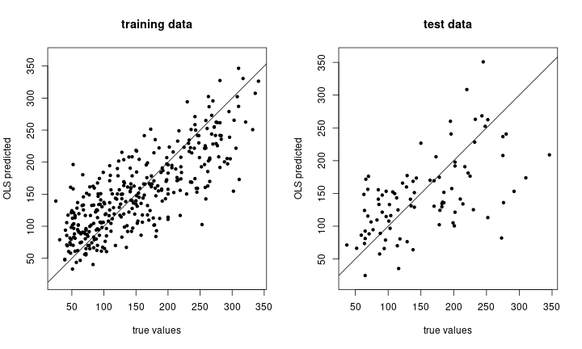

```r
plot(training_d$y, predict(ols), xlab="true values", ylab="OLS predicted", main="training data", pch=20, asp=1)
abline(0,1)
plot(test_d$y, ols_pred, xlab="true values", ylab="OLS predicted", main="test data", pch=20, asp=1)
abline(0,1)
```

## A sparsifying prior

We have a lot of predictors: 64 of them. A good guess is that only a few are really useful. So, we can put a *sparsifying* prior on the coefficients, i.e., $\beta$s in
$$\begin{aligned}
y = \beta_0 + \beta_1 x_1 + \cdots \beta_n x_n + \epsilon
\end{aligned}$$

# Sparseness and scale mixtures

## Encouraging sparseness

Suppose we do regression with a *large* number of predictor variables.

The resulting coefficients are **sparse** if most are zero.

The idea is to “encourage” all the coefficients to be zero, **unless** they *really* want to be nonzero, in which case we let them be whatever they want.

This tends to discourage overfitting.

> The idea is to “encourage” all the coefficients to be zero, **unless** they *really* want to be nonzero, in which case we let them be whatever they want.

To do this, we want a prior which is very peak-ey at zero *but* flat away from zero (“spike-and-slab”).

*Options:*

1. Student’s $t$ (e.g., Cauchy)
2. Scale mixtures

Compare the Normal

$$\begin{aligned}
X \sim \Normal(0,1)
\end{aligned}$$

to the “exponential scale mixture of Normals”,

$$\begin{aligned}
X &\sim \Normal(0,\sigma) \\
\sigma &\sim \Exp(1) .
\end{aligned}$$

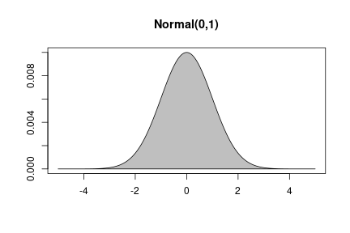

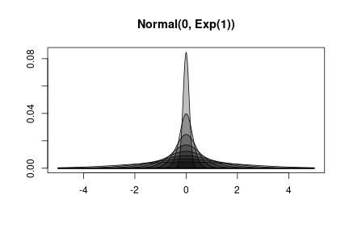

## Exercise:

1. Write a function `rexponormal(n, lambda)` that returns `n` independent draws from:
   $$\begin{aligned}
   X &\sim \Normal(0,\sigma) \\
   \sigma &\sim \Exp(\lambda) .
   \end{aligned}$$
2. Find, by trial-and-error, a value of $\lambda$ so that this give you random numbers that are usually between $\pm 200$ but are sometimes as big as $\pm 500$ or $\pm 1000$.

## Why use a scale mixture?

1. Lets the data choose the appropriate scale of variation.
2. Weakly encourages $\sigma$ to be small: so, as much variation as possible is explained by *signal* instead of *noise*.
3. Gets you a prior that is more peaked at zero and flatter otherwise.

## A strongly sparsifying prior

The “horseshoe”:

$$\begin{aligned}
\beta_j &\sim \Normal(0, \lambda_j) \\
\lambda_j &\sim \Cauchy(0, \tau) \\
\tau &\sim \Unif(0, 1)
\end{aligned}$$

# Application

## The plan

Fit a linear model to the `diabetes` dataset with:

1. no prior
2. horseshoe priors

## OLS in brms

```r
xy <- cbind(data.frame(y=diabetes$y), diabetes$x2)
names(xy) <- gsub("[:^]", "_", names(xy))

# ols
brms_ols <- brm(y ~ ., data=xy, family=gaussian(link='identity'), file="cache/diabetes_ols.rds")
```

## horseshoe in brms

```r
brms_hs <- brm(y ~ ., data=xy, family=gaussian(link='identity'),
               prior=c(set_prior(horseshoe(), class="b")), file="cache/diabetes_hs_prior.rds")
```

## Crossvalidation error function

```r
brms_kfold <- function (K, models) {
    stopifnot(!is.null(names(models)))
    Kfold <- sample(rep(1:K, nrow(xy)/K))
    results <- data.frame(rep=1:K)
    for (j in seq_along(models)) {
        train <- test <- rep(NA, K)
        for (k in 1:K) {
            new_fit <- update(models[[j]], newdata=subset(xy, Kfold != k))
            train[k] <- sqrt(mean(resid(new_fit)[,"Estimate"]^2))
            test_y <- xy$y[Kfold == k]
            test[k] <- sqrt(mean(
                   (test_y - predict(new_fit, newdata=subset(xy, Kfold==k))[,"Estimate"])^2 ))
        }
        results[[paste0(names(models)[j], "_train")]] <- train
        results[[paste0(names(models)[j], "_test")]] <- test
    }
    return(results)
}
```

```r
brms_xvals <- brms_kfold(5, list('ols'=brms_ols, 'horseshoe'=brms_hs))
```

## Crossvalidation results

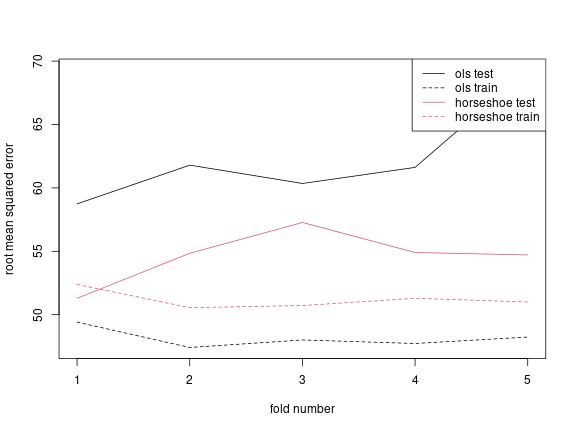

## Coefficients:

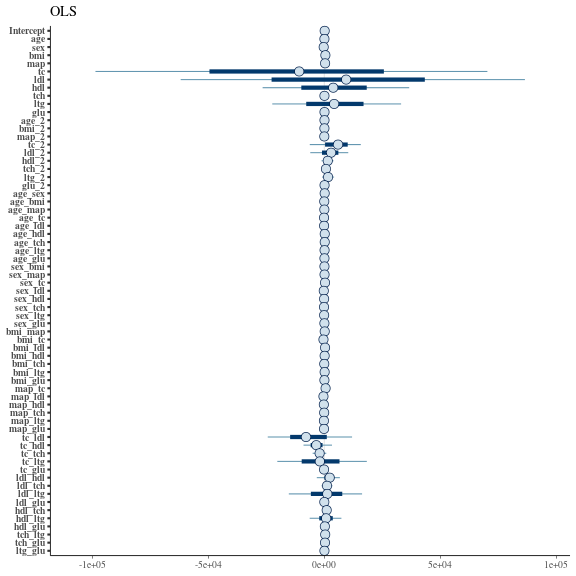

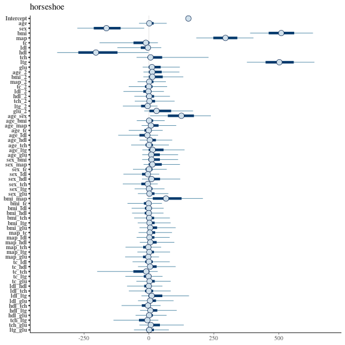

## Coefficients, zoomed in:

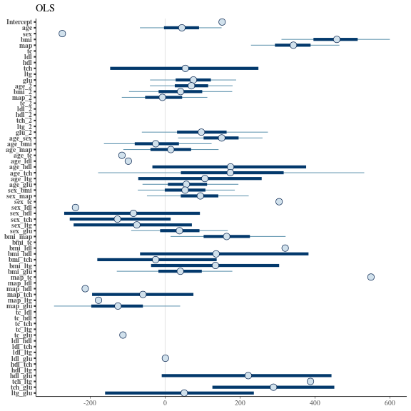

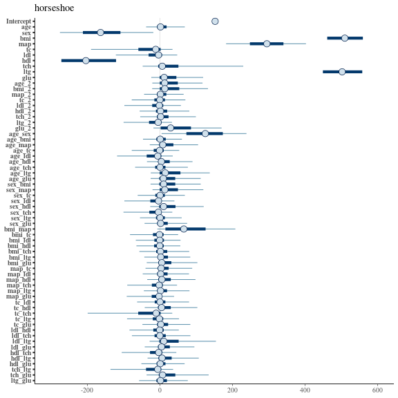

# Model fit

## What’s an appropriate noise distribution?

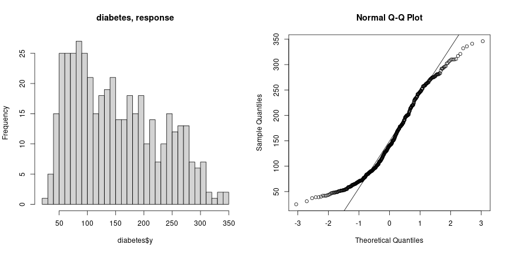

## Aside: quantile-quantile plots

The idea is to plot the *quantiles* of each distribution against each other.

If these are *datasets*, this means just plotting their *sorted values* against each other.

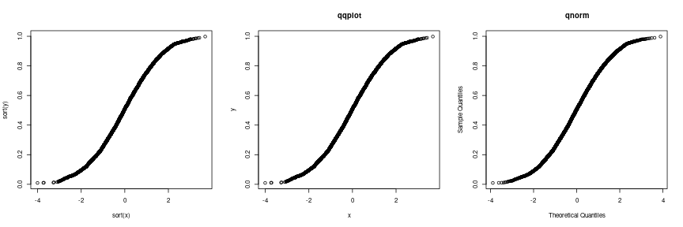

```r
x <- rnorm(1e4)
y <- rbeta(1e4, 2, 2)
plot(sort(x), sort(y)); qqplot(x, y, main="qqplot"); qqnorm(y, main="qnorm")
```

## The noise distribution applies to the *residuals*!

$$\begin{aligned}
y_i &= \sum_j \beta_j x_{ij} + \epsilon_i \\
\epsilon_i &\sim \Normal(0, \sigma^2) .
\end{aligned}$$

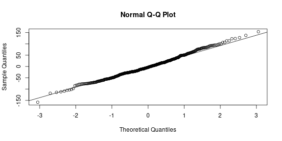

```r
ols_resids <- resid(lm(y ~ ., data=xy))
qqnorm(ols_resids)
qqline(ols_resids)
```

## Posterior preditive checks:

```r
pp_check(brms_hs)
```

```
## Using 10 posterior draws for ppc type 'dens_overlay' by default.
```

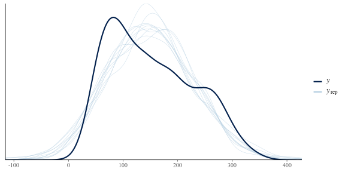

# More general crossvalidation

## `brms::kfold`

The `kfold` function will *automatically* do $k$-fold crossvalidation! For instance:

```r
(khs <- brms::kfold(brms_hs, K=5))
```

```
## Fitting model 1 out of 5
```

```
## Fitting model 2 out of 5
```

```
## Fitting model 3 out of 5
```

```
## Fitting model 4 out of 5
```

```
## Fitting model 5 out of 5
```

```
##
## Based on 5-fold cross-validation
##
##            Estimate   SE
## elpd_kfold  -2405.0 13.7
## p_kfold        33.3  3.1
## kfoldic      4810.0 27.4
```

`elpd` = “expected log posterior density”

[output not shown]